# **<<< Only Problem 2 and 4 will be graded >>>**

```python
import matplotlib.pyplot as plt
import numpy as np
import IPython.display as ipd
%matplotlib inline
import os
from scipy import signal,fftpack
from skimage.io import imread
import cv2
```

## Problem 1

Find the Fourier series of the following periodic function \

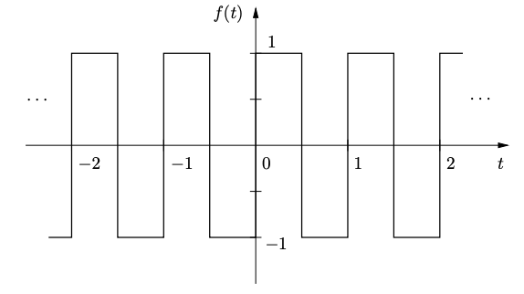

## Problem 2

Find th Fourier Series (FS) of the periodic function $ x(t) $ which are provided as follows.

1. $ x(t) = \frac{\pi t^3}{2} ; -1 < t < 1$
2. $ x(t) = \pi - t; -\pi <= t <= \pi$
3. $ x(t) = t^2 + \sin^3(\pi t) ; -1 <= t <= 1$

## Problem 3

Find the Fourier tranform of the following signals in terms of $X(j\omega)$, the Fourier tranform of $x(t)$ $ \left( \mathscr{F} \left\{ x(t) \right\} = X(j\omega) \right) $

1. $x(-t)$
2. $x_e(t) = \frac{x(t) + x(-t)}{2}$
3. $x_o(t) = \frac{x(t) - x(-t)}{2}$

## Problem 4

Let $ \mathscr{F} \left\{ x(t) \right\} = X(j\omega) = \textrm{rect} \left[ (\omega-1)/2\right] $. Find Fourier tranform of

1. $x(-2t+4)$
2. $(t-1)x(t-1)$
3. $ t\frac{dx(t)}{dt}$
4. $ x(2t-1)\exp[-j2t]$
5. $ x(t)*x(t-1)$

## Problem 5.1

### Proof

$ \mathscr{F} \left\{ e^{-|t|} \right\} = \mathscr{F} \left\{ exp(-|t|) \right\} = \frac{2}{\omega^2+1}$

## Problem 5.2

Using the outcome obtained in Problem 5.1, Find the Fourier Transform of the given equation.

1. $\frac{d}{dt} (e^{-|t|})$
2. $ exp(3t-|2t+2|)$
3. $ \frac{1}{2\pi t^2 + 1}$

## Problem 6

For each of the following Fourier transform ($X(j\omega)$), use Fourier transform properties to determine the corresponding time-domain signal ($x(t)$)

1. $X(j\omega) = u(\omega) - u(\omega -2)$
2. $X(j\omega) = \cos(2\omega)\sin \left(\frac{\omega}{2} \right)$

## Problem 7

Proof

$\int_{-\infty}^{\infty} {|x(t)|}^2 dt = \frac{1}{2\pi} \int_{-\infty}^{ \infty } |X(j\omega)|^2 d\omega$

## Problem 8

Determine a signal $x(t)$ which has its Fourier transform

$X(j\omega) = \delta(\omega)-\delta(\omega-a_0\pi)-\delta(\omega-a_1)$

and the impulse response in time-domain is $h(t) = u(t) - u(t-2b_0)$

1. Show how to find $x(t)$ and determine whether it is periodic?
2. Show how to find $y(t) = x(t) * h(t) $ and determine whether it is periodic?

Verify you results by sketching $x(t)$, $h(t)$, $y(t)$, $X(j\omega)$, $H(j\omega)$ and $Y(j\omega)$. Note that for the complex number, plot only its magnitude.